# R-Report VirágZábó

Missing values were found in the dataset below the following variables: country_code: 864, Terrorism: 1398, Conflict: 1398. Since our hypothesis does not respect these variables, it is not worth to pay effort to replace the missing values. Thus, they can be simply dropped from the data set.

```r
sapply(my_data,function(x) sum(is.na(x)))
```

```
##                        country                   country_code
##                              0                            864
##                           year        cardiovascular_diseases
##                              0                              0
##                        cancers           respiratory_diseases
##                              0                              0
##                       diabetes                       dementia
##                              0                              0
##   lower_respiratory_infections                neonatal_deaths
##                              0                              0
##             diarrheal_diseases                 road_accidents
##                              0                              0
##                  liver_disease                   tuberculosis
##                              0                              0
##                 kidney_disease             digestive_diseases
##                              0                              0
##                       HIV_AIDS                        suicide
##                              0                              0
##                        malaria                       homicide
##                              0                              0
##        nutritional_deficiences                      meningtis
##                              0                              0
##    protein_energy_malnutrition                       drowning
##                              0                              0
##                 maternal_death              parkinson_disease
##                              0                              0
##              alcohol_disorders intestinal_infectious_diseases
##                              0                              0
##                 drug_disorders                      hepatitis
##                              0                              0
##                           fire                  heat_realeted
##                              0                              0
##              natural_disasters                       conflict
##                              0                           1398
##                      terrorism
##                           1398
```

```r
my_data = subset(my_data, select = -c(2, 34, 35))
str(my_data)
```

```
## 'data.frame':    6156 obs. of  32 variables:
##  $ country                       : chr  "Afghanistan" "Afghanistan" "Afghanistan" "Afghanistan" ...
##  $ year                          : num  1990 1991 1992 1993 1994 ...
##  $ cardiovascular_diseases       : num  17.6 17.8 18.4 19 19.1 ...
##  $ cancers                       : num  4.03 4.05 4.17 4.27 4.26 ...
##  $ respiratory_diseases          : num  2.11 2.13 2.21 2.28 2.31 ...
##  $ diabetes                      : num  3.83 3.82 3.9 3.97 3.97 ...
##  $ dementia                      : num  0.531 0.532 0.54 0.554 0.55 ...
##  $ lower_respiratory_infections  : num  10.89 10.36 10.1 9.87 9.53 ...
##  $ neonatal_deaths               : num  9.18 8.94 8.84 8.68 8.38 ...
##  $ diarrheal_diseases            : num  2.5 2.57 2.71 3.36 3.08 ...
##  $ road_accidents                : num  3.72 3.73 3.82 3.88 3.86 ...
##  $ liver_disease                 : num  0.837 0.846 0.875 0.901 0.905 ...
##  $ tuberculosis                  : num  5.88 5.89 6.03 6.16 6.14 ...
##  $ kidney_disease                : num  1.68 1.67 1.7 1.73 1.73 ...
```

[output cut: 18 more lines]

Exploring the Nature of the Variables

```r
summary(my_data)
```

```
##    country               year      cardiovascular_diseases    cancers
##  Length:6156        Min.   :1990   Min.   : 1.429          Min.   : 0.5823
##  Class :character   1st Qu.:1996   1st Qu.:18.744          1st Qu.: 6.9266
##  Mode  :character   Median :2003   Median :30.652          Median :13.3075
##                     Mean   :2003   Mean   :29.935          Mean   :14.3865
##                     3rd Qu.:2010   3rd Qu.:38.447          3rd Qu.:21.3591
##                     Max.   :2016   Max.   :67.388          Max.   :33.6175
##  respiratory_diseases    diabetes          dementia
##  Min.   : 0.298       Min.   : 0.3271   Min.   : 0.04475
##  1st Qu.: 2.263       1st Qu.: 3.1983   1st Qu.: 1.01276
##  Median : 3.628       Median : 4.9910   Median : 2.52541
##  Mean   : 4.100       Mean   : 6.2862   Mean   : 3.22056
##  3rd Qu.: 5.379       3rd Qu.: 7.9318   3rd Qu.: 4.33010
##  Max.   :16.289       Max.   :35.8162   Max.   :16.67248
##  lower_respiratory_infections neonatal_deaths    diarrheal_diseases
##  Min.   : 0.6846              Min.   : 0.04071   Min.   : 0.008251
##  1st Qu.: 3.2098              1st Qu.: 0.68559   1st Qu.: 0.178763
##  Median : 5.1385              Median : 3.89183   Median : 0.767651
##  Mean   : 5.8392              Mean   : 4.56666   Mean   : 3.195824
##  3rd Qu.: 8.1610              3rd Qu.: 7.74003   3rd Qu.: 5.285289
##  Max.   :20.0352              Max.   :17.80683   Max.   :25.184488
##  road_accidents    liver_disease      tuberculosis      kidney_disease
##  Min.   : 0.2784   Min.   : 0.1929   Min.   : 0.01088   Min.   :0.05624
##  1st Qu.: 1.3558   1st Qu.: 1.3378   1st Qu.: 0.24386   1st Qu.:0.90262
##  Median : 1.9287   Median : 1.8255   Median : 0.91365   Median :1.73135
##  Mean   : 2.5312   Mean   : 2.1242   Mean   : 2.13261   Mean   :2.08838
##  3rd Qu.: 2.9033   3rd Qu.: 2.5360   3rd Qu.: 3.32878   3rd Qu.:2.96065
##  Max.   :20.9009   Max.   :11.6471   Max.   :16.46586   Max.   :9.94769
##  digestive_diseases    HIV_AIDS           suicide           malaria
##  Min.   :0.3136     Min.   : 0.00000   Min.   : 0.1016   Min.   : 0.000000
##  1st Qu.:1.5051     1st Qu.: 0.08141   1st Qu.: 0.6917   1st Qu.: 0.000000
##  Median :1.9312     Median : 0.43797   Median : 1.1767   Median : 0.002715
##  Mean   :1.9697     Mean   : 3.35177   Mean   : 1.3914   Mean   : 1.800705
##  3rd Qu.:2.2885     3rd Qu.: 2.33436   3rd Qu.: 1.7953   3rd Qu.: 0.478271
##  Max.   :5.1587     Max.   :62.19363   Max.   :15.4120   Max.   :24.425962
##     homicide       nutritional_deficiences   meningtis
##  Min.   : 0.0452   Min.   : 0.00375        Min.   :0.02799
##  1st Qu.: 0.2396   1st Qu.: 0.09012        1st Qu.:0.11099
##  Median : 0.5155   Median : 0.39700        Median :0.35340
##  Mean   : 0.9830   Mean   : 1.09517        Mean   :0.78312
```

[output cut: 15 more lines]

```
##  Max.   :1.592211   Max.   :3.08053   Max.   :2.2765134
##  drug_disorders       hepatitis             fire         heat_realeted
##  Min.   :0.001797   Min.   :0.004848   Min.   :0.05691   Min.   :0.007108
##  1st Qu.:0.058298   1st Qu.:0.037685   1st Qu.:0.18833   1st Qu.:0.042403
##  Median :0.120883   Median :0.110875   Median :0.31880   Median :0.069565
##  Mean   :0.181023   Mean   :0.161039   Mean   :0.33422   Mean   :0.102844
##  3rd Qu.:0.234596   3rd Qu.:0.243074   3rd Qu.:0.43331   3rd Qu.:0.114803
##  Max.   :1.313466   Max.   :1.583289   Max.   :1.34369   Max.   :1.165286
##  natural_disasters
##  Min.   : 0.00000
##  1st Qu.: 0.00000
##  Median : 0.00000
##  Mean   : 0.09451
##  3rd Qu.: 0.01695
##  Max.   :65.29420
```

###Check for outliers The source of the data is: ourworldindata.org Referring to the consideration of datacleaning, the dataset is already cleared, I have checked it several times, therefore datacleaning is not needed in this case. The source of the data could be checked here also: https://ourworldindata.org/what-does-the-world-die-from

```r
summary(my_data)
```

```
##    country               year      cardiovascular_diseases    cancers
##  Length:6156        Min.   :1990   Min.   : 1.429          Min.   : 0.5823
##  Class :character   1st Qu.:1996   1st Qu.:18.744          1st Qu.: 6.9266
##  Mode  :character   Median :2003   Median :30.652          Median :13.3075
##                     Mean   :2003   Mean   :29.935          Mean   :14.3865
##                     3rd Qu.:2010   3rd Qu.:38.447          3rd Qu.:21.3591
##                     Max.   :2016   Max.   :67.388          Max.   :33.6175
##  respiratory_diseases    diabetes          dementia
##  Min.   : 0.298       Min.   : 0.3271   Min.   : 0.04475
##  1st Qu.: 2.263       1st Qu.: 3.1983   1st Qu.: 1.01276
##  Median : 3.628       Median : 4.9910   Median : 2.52541
##  Mean   : 4.100       Mean   : 6.2862   Mean   : 3.22056
##  3rd Qu.: 5.379       3rd Qu.: 7.9318   3rd Qu.: 4.33010
##  Max.   :16.289       Max.   :35.8162   Max.   :16.67248
##  lower_respiratory_infections neonatal_deaths    diarrheal_diseases
##  Min.   : 0.6846              Min.   : 0.04071   Min.   : 0.008251
##  1st Qu.: 3.2098              1st Qu.: 0.68559   1st Qu.: 0.178763
##  Median : 5.1385              Median : 3.89183   Median : 0.767651
##  Mean   : 5.8392              Mean   : 4.56666   Mean   : 3.195824
##  3rd Qu.: 8.1610              3rd Qu.: 7.74003   3rd Qu.: 5.285289
##  Max.   :20.0352              Max.   :17.80683   Max.   :25.184488
##  road_accidents    liver_disease      tuberculosis      kidney_disease
##  Min.   : 0.2784   Min.   : 0.1929   Min.   : 0.01088   Min.   :0.05624
##  1st Qu.: 1.3558   1st Qu.: 1.3378   1st Qu.: 0.24386   1st Qu.:0.90262
##  Median : 1.9287   Median : 1.8255   Median : 0.91365   Median :1.73135
##  Mean   : 2.5312   Mean   : 2.1242   Mean   : 2.13261   Mean   :2.08838
##  3rd Qu.: 2.9033   3rd Qu.: 2.5360   3rd Qu.: 3.32878   3rd Qu.:2.96065
##  Max.   :20.9009   Max.   :11.6471   Max.   :16.46586   Max.   :9.94769
##  digestive_diseases    HIV_AIDS           suicide           malaria
##  Min.   :0.3136     Min.   : 0.00000   Min.   : 0.1016   Min.   : 0.000000
##  1st Qu.:1.5051     1st Qu.: 0.08141   1st Qu.: 0.6917   1st Qu.: 0.000000
##  Median :1.9312     Median : 0.43797   Median : 1.1767   Median : 0.002715
##  Mean   :1.9697     Mean   : 3.35177   Mean   : 1.3914   Mean   : 1.800705
##  3rd Qu.:2.2885     3rd Qu.: 2.33436   3rd Qu.: 1.7953   3rd Qu.: 0.478271
##  Max.   :5.1587     Max.   :62.19363   Max.   :15.4120   Max.   :24.425962
##     homicide       nutritional_deficiences   meningtis
##  Min.   : 0.0452   Min.   : 0.00375        Min.   :0.02799
##  1st Qu.: 0.2396   1st Qu.: 0.09012        1st Qu.:0.11099
##  Median : 0.5155   Median : 0.39700        Median :0.35340
##  Mean   : 0.9830   Mean   : 1.09517        Mean   :0.78312
```

[output cut: 15 more lines]

```
##  Max.   :1.592211   Max.   :3.08053   Max.   :2.2765134
##  drug_disorders       hepatitis             fire         heat_realeted
##  Min.   :0.001797   Min.   :0.004848   Min.   :0.05691   Min.   :0.007108
##  1st Qu.:0.058298   1st Qu.:0.037685   1st Qu.:0.18833   1st Qu.:0.042403
##  Median :0.120883   Median :0.110875   Median :0.31880   Median :0.069565
##  Mean   :0.181023   Mean   :0.161039   Mean   :0.33422   Mean   :0.102844
##  3rd Qu.:0.234596   3rd Qu.:0.243074   3rd Qu.:0.43331   3rd Qu.:0.114803
##  Max.   :1.313466   Max.   :1.583289   Max.   :1.34369   Max.   :1.165286
##  natural_disasters
##  Min.   : 0.00000
##  1st Qu.: 0.00000
##  Median : 0.00000
##  Mean   : 0.09451
##  3rd Qu.: 0.01695
##  Max.   :65.29420
```

###Tests of Normality

```r
str(my_data)
```

```
## 'data.frame':    6156 obs. of  32 variables:
##  $ country                       : chr  "Afghanistan" "Afghanistan" "Afghanistan" "Afghanistan" ...
##  $ year                          : num  1990 1991 1992 1993 1994 ...
##  $ cardiovascular_diseases       : num  17.6 17.8 18.4 19 19.1 ...
##  $ cancers                       : num  4.03 4.05 4.17 4.27 4.26 ...
##  $ respiratory_diseases          : num  2.11 2.13 2.21 2.28 2.31 ...
##  $ diabetes                      : num  3.83 3.82 3.9 3.97 3.97 ...
##  $ dementia                      : num  0.531 0.532 0.54 0.554 0.55 ...
##  $ lower_respiratory_infections  : num  10.89 10.36 10.1 9.87 9.53 ...
##  $ neonatal_deaths               : num  9.18 8.94 8.84 8.68 8.38 ...
##  $ diarrheal_diseases            : num  2.5 2.57 2.71 3.36 3.08 ...
##  $ road_accidents                : num  3.72 3.73 3.82 3.88 3.86 ...
##  $ liver_disease                 : num  0.837 0.846 0.875 0.901 0.905 ...
##  $ tuberculosis                  : num  5.88 5.89 6.03 6.16 6.14 ...
##  $ kidney_disease                : num  1.68 1.67 1.7 1.73 1.73 ...
```

[output cut: 18 more lines]

```r
df <- data.frame(cause_of_death=colnames(my_data)[3:31],
                p_value=NA)
df
```

```
##                    cause_of_death p_value
## 1         cardiovascular_diseases      NA
## 2                         cancers      NA
## 3            respiratory_diseases      NA
## 4                        diabetes      NA
## 5                        dementia      NA
## 6    lower_respiratory_infections      NA
## 7                 neonatal_deaths      NA
## 8              diarrheal_diseases      NA
## 9                  road_accidents      NA
## 10                  liver_disease      NA
## 11                   tuberculosis      NA
## 12                 kidney_disease      NA
## 13             digestive_diseases      NA
## 14                       HIV_AIDS      NA
## 15                        suicide      NA
## 16                        malaria      NA
## 17                       homicide      NA
## 18        nutritional_deficiences      NA
## 19                      meningtis      NA
## 20    protein_energy_malnutrition      NA
## 21                       drowning      NA
## 22                 maternal_death      NA
## 23              parkinson_disease      NA
## 24              alcohol_disorders      NA
## 25 intestinal_infectious_diseases      NA
## 26                 drug_disorders      NA
## 27                      hepatitis      NA
## 28                           fire      NA
## 29                  heat_realeted      NA
```

```r
x=0

for(i in 3:31){
x=x+1
a <- ks.test(my_data[,i], "pnorm")
df[x,2] <- a$p.value
}
df
```

```
##                    cause_of_death p_value
## 1         cardiovascular_diseases       0
## 2                         cancers       0
## 3            respiratory_diseases       0
## 4                        diabetes       0
## 5                        dementia       0
## 6    lower_respiratory_infections       0
## 7                 neonatal_deaths       0
## 8              diarrheal_diseases       0
## 9                  road_accidents       0
## 10                  liver_disease       0
## 11                   tuberculosis       0
## 12                 kidney_disease       0
## 13             digestive_diseases       0
## 14                       HIV_AIDS       0
## 15                        suicide       0
## 16                        malaria       0
## 17                       homicide       0
## 18        nutritional_deficiences       0
## 19                      meningtis       0
## 20    protein_energy_malnutrition       0
## 21                       drowning       0
## 22                 maternal_death       0
## 23              parkinson_disease       0
## 24              alcohol_disorders       0
## 25 intestinal_infectious_diseases       0
## 26                 drug_disorders       0
## 27                      hepatitis       0
## 28                           fire       0
## 29                  heat_realeted       0
```

#Hypothesis I In general significantly more Hungarian people died of cardiovascular diseases than French people.

```r
my_data_HUN <- filter(my_data, country=="Hungary")
my_data_HUN
```

```
##    country year cardiovascular_diseases  cancers respiratory_diseases diabetes
## 1  Hungary 1990                50.84255 21.34999             3.708068 2.653938
## 2  Hungary 1991                50.55059 21.61199             3.645415 2.566757
## 3  Hungary 1992                50.23127 21.92091             3.618330 2.500637
## 4  Hungary 1993                50.03364 22.19328             3.578716 2.446789
## 5  Hungary 1994                49.77276 22.58595             3.525919 2.418968
## 6  Hungary 1995                49.72090 22.98598             3.453587 2.416968
## 7  Hungary 1996                49.75871 23.45931             3.363918 2.448013
## 8  Hungary 1997                49.47164 23.95886             3.265800 2.490856
## 9  Hungary 1998                49.31895 24.30961             3.179596 2.562174
## 10 Hungary 1999                49.19608 24.61068             3.201049 2.649983
## 11 Hungary 2000                48.88703 25.09918             3.148147 2.711521
## 12 Hungary 2001                48.73082 25.48231             3.117668 2.755617
## 13 Hungary 2002                48.56192 25.70292             3.185596 2.909667
## 14 Hungary 2003                48.39380 25.86249             3.328510 3.050870
```

[output cut: 181 more lines]

```r
my_data_FR <- filter(my_data, country=="France")
my_data_FR
```

```
##    country year cardiovascular_diseases  cancers respiratory_diseases diabetes
## 1   France 1990                34.07554 27.10975             4.609240 3.926773
## 2   France 1991                33.64440 27.37465             4.553510 3.904138
## 3   France 1992                33.25775 27.64643             4.536114 3.890925
## 4   France 1993                33.02930 27.77573             4.543955 3.927483
## 5   France 1994                32.79334 27.88690             4.525039 3.967141
## 6   France 1995                32.80125 27.90773             4.554680 4.033376
## 7   France 1996                32.68613 28.03173             4.589675 4.105242
## 8   France 1997                32.52627 28.14368             4.590938 4.213686
## 9   France 1998                32.29232 28.31878             4.559960 4.388850
## 10  France 1999                32.11054 28.46207             4.438505 4.551424
## 11  France 2000                31.81375 28.70721             4.173195 4.658253
## 12  France 2001                31.50365 29.01496             4.007742 4.773783
## 13  France 2002                31.18642 29.33639             3.921145 4.872343
## 14  France 2003                30.88441 29.58268             3.872545 4.955872
```

[output cut: 181 more lines]

```r
wilcox.test(my_data_HUN$cardiovascular_diseases, my_data_FR$cardiovascular_diseases)
```

```
##
##  Wilcoxon rank sum exact test
##
## data:  my_data_HUN$cardiovascular_diseases and my_data_FR$cardiovascular_diseases
## W = 729, p-value = 1.027e-15
## alternative hypothesis: true location shift is not equal to 0
```

```r
mean(my_data_HUN$cardiovascular_diseases)
```

```
## [1] 48.84803
```

```r
mean(my_data_FR$cardiovascular_diseases)
```

```
## [1] 30.78902
```

```r
tablenew <- filter(my_data, country=="Hungary" | country== "France")
tablenew
```

```
##    country year cardiovascular_diseases  cancers respiratory_diseases diabetes
## 1   France 1990                34.07554 27.10975             4.609240 3.926773
## 2   France 1991                33.64440 27.37465             4.553510 3.904138
## 3   France 1992                33.25775 27.64643             4.536114 3.890925
## 4   France 1993                33.02930 27.77573             4.543955 3.927483
## 5   France 1994                32.79334 27.88690             4.525039 3.967141
## 6   France 1995                32.80125 27.90773             4.554680 4.033376
## 7   France 1996                32.68613 28.03173             4.589675 4.105242
## 8   France 1997                32.52627 28.14368             4.590938 4.213686
## 9   France 1998                32.29232 28.31878             4.559960 4.388850
## 10  France 1999                32.11054 28.46207             4.438505 4.551424
## 11  France 2000                31.81375 28.70721             4.173195 4.658253
## 12  France 2001                31.50365 29.01496             4.007742 4.773783
## 13  France 2002                31.18642 29.33639             3.921145 4.872343
## 14  France 2003                30.88441 29.58268             3.872545 4.955872
```

[output cut: 370 more lines]

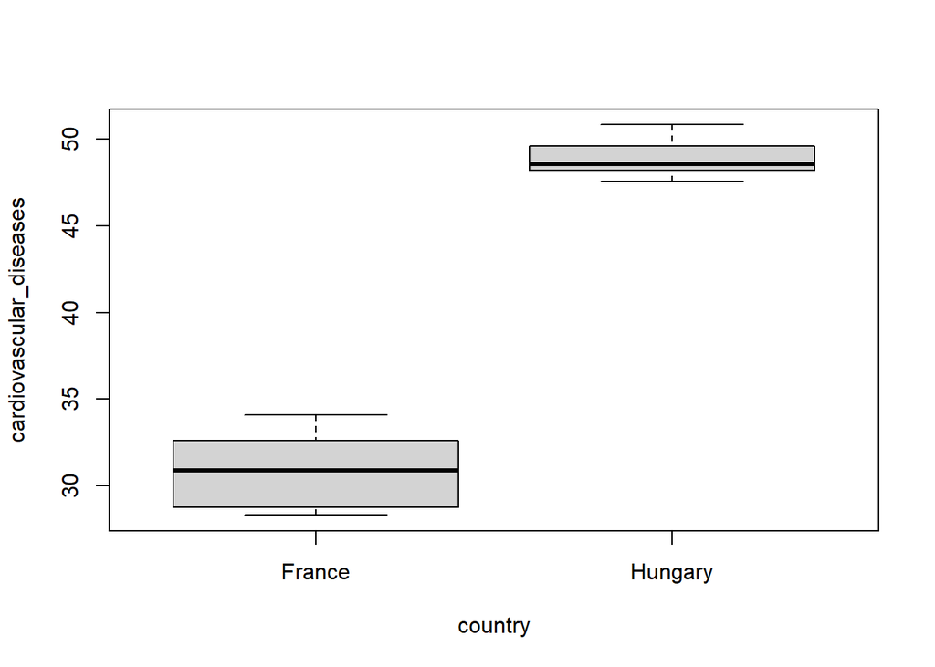

```r
boxplot(cardiovascular_diseases ~ country, data = tablenew)
```

The Wilcoxon rank test indicated that in general significantly more Hungarian people (*M* = 48.85) died of cardiovascular diseases than French people (*M* = 30,79), W = 729, *p* < .001.

#Hypothesis II In general significantly more Hungarian people died of cancer than French people.

```r
wilcox.test(my_data_HUN$cancers, my_data_FR$cancers)
```

```
##
##  Wilcoxon rank sum exact test
##
## data:  my_data_HUN$cancers and my_data_FR$cancers
## W = 0, p-value = 1.027e-15
## alternative hypothesis: true location shift is not equal to 0
```

```r
mean(my_data_HUN$cancers)
```

```
## [1] 24.86135
```

```r
mean(my_data_FR$cancers)
```

```
## [1] 29.38824
```

```r
tablenew <- filter(my_data, country=="Hungary" | country== "France")
tablenew
```

```
##    country year cardiovascular_diseases  cancers respiratory_diseases diabetes
## 1   France 1990                34.07554 27.10975             4.609240 3.926773
## 2   France 1991                33.64440 27.37465             4.553510 3.904138
## 3   France 1992                33.25775 27.64643             4.536114 3.890925
## 4   France 1993                33.02930 27.77573             4.543955 3.927483
## 5   France 1994                32.79334 27.88690             4.525039 3.967141
## 6   France 1995                32.80125 27.90773             4.554680 4.033376
## 7   France 1996                32.68613 28.03173             4.589675 4.105242
## 8   France 1997                32.52627 28.14368             4.590938 4.213686
## 9   France 1998                32.29232 28.31878             4.559960 4.388850
## 10  France 1999                32.11054 28.46207             4.438505 4.551424
## 11  France 2000                31.81375 28.70721             4.173195 4.658253
## 12  France 2001                31.50365 29.01496             4.007742 4.773783
## 13  France 2002                31.18642 29.33639             3.921145 4.872343
## 14  France 2003                30.88441 29.58268             3.872545 4.955872
```

[output cut: 370 more lines]

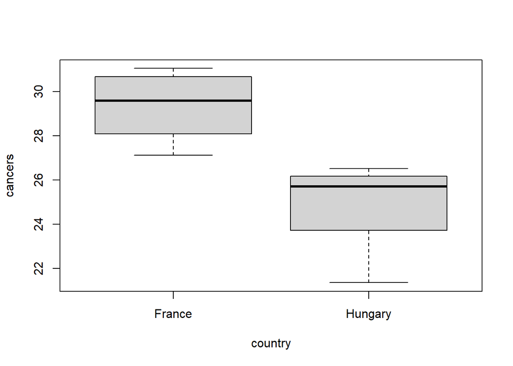

```r
boxplot(cancers ~ country, data = tablenew)
```

The Wilcoxon rank test indicated that in general not significantly more Hungarian people (*M* = 24.86) died of cancer than French people (*M* = 29.39), W = 0, *p* < .001. The Wilcoxon rank test indicated that in general significantly more French people (*M* = 29.39) died of cancer than Hungarian people (*M* = 24.86), W = 0, *p* < .001.

Note: Referring to the validity of the test, it is important to take into consideration the small sample size on which the test was performed.